# Practica02

Brian Sandoval

2024-05-22

```r
library(XML)
library(httr)
library(dplyr)
library(stringr)
library(data.table)
library(gridExtra)
library(htmlTable)
library(tidyverse)
```

## Practica 02:

1. Descargar la página web de la URL indicada, y almacenarlo en un formato de R apto para ser tratado.

```r
html <- GET("https://www.mediawiki.org/wiki/MediaWiki")
contenido <- content(html, as = "text")
parsedHtml <- htmlParse(contenido, asText = TRUE)
```

2. Analizar el contenido de la web, buscando el título de la página (que en HTML se etiqueta como “title”).

RSPT: El título de la página es: MediaWiki.

3. Analizar el contenido de la web, buscando todos los enlaces (que en HTML se etiquetan como “a”), buscando el texto del enlace, así como la URL.

4. Generar una tabla con cada enlace encontrado, indicando el texto que acompaña el enlace, y el número de veces que aparece un enlace con ese mismo objetivo.

5. Para cada enlace, seguirlo e indicar si está activo (podemos usar el código de status HTTP al hacer una petición a esa URL).

## Pregunta 02:

1. Un histograma con la frecuencia de aparición de los enlaces, pero separado por URLs absolutas (con “http…”) y URLs relativas.

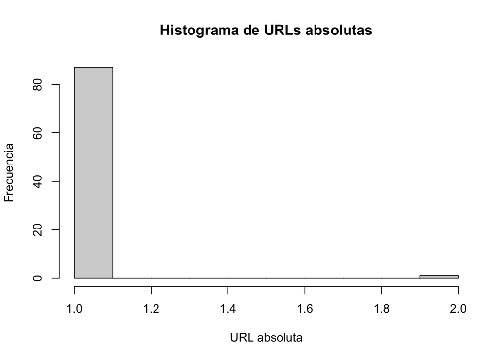

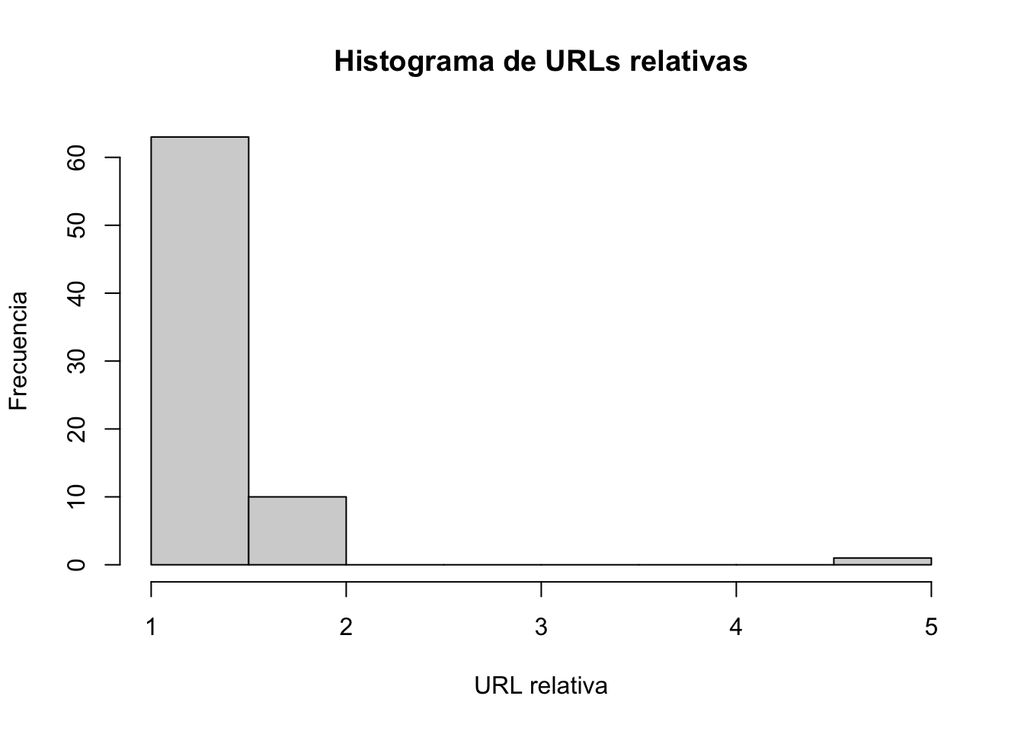

2. Un gráfico de barras indicando la suma de enlaces que apuntan a otros dominios o servicios (distinto a https://www.mediawiki.org en el caso de ejemplo) vs. la suma de los otros enlaces.

[figure not shown]

3. Un gráfico de tarta (pie chart) indicando los porcentajes de Status de nuestro análisis.

Azul = 200 Naranja = 404

[figure not shown]